# Quillback Rockfish

*Sebastes maliger*

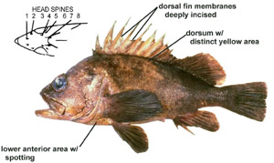

**Peritoneum color:** light **Shape between eyes:** convex to concave

**Counts:** D:XIII,12-14, Ar:6-7, P1:16-18, GR:29-33, LLp:34-48, LLs:39-45, V:26

**Occurence:** Gulf of Alaska - Southern California

**Depth:** 274 meters **Size:** 61 cm **Species code:** 30320

**Similar species:**

- *Brown rockfish* - body brown w/ dark mottling; dorsal-fin membranes not deeply incised; head spine count typically differs
- *Copper rockfish* - posterior two-thirds of lateral line clear; dorsal-fin membranes not deeply incised; anal rays typically 6 (typically 7 in Quillback RF)
- *China rockfish* - body black w/ yellow stripe along lateral line and across nape; dorsal-fin margin not deeply incised

Back to Group

**Corrections:** If you see mistakes or want to suggest changes, please create an [issue](https://github.com/zoyafuso-NOAA/RACE_Survey_App/issues) on the source repository or

*reach out to Liz Dawson (Liz.Dawson AT noaa.gov).*